# Midterm 1 Project

Amelia Le

2023-10-04

```r
# Load the dataset from local env
rent <- read.csv('rent.csv')
```

# A. Analyzing Trends in San Jose Rental Prices

### 1. How many 1 bedroom listings from Santa Clara county are in this dataset?

```r
santa_clara <- rent |>
  filter(county == "santa clara", beds == "1") |>
  summarise(sc_len = length(beds))
```

There are a total of 12455 listings for 1 bedroom apartments from Santa Clara county contained in this dataset.

### 2. What is the median price for a 1 bedroom listing in Santa Clara county in 2018?

```r
# filter the subset that only contain 1 bedroom house within Santa Clara county in 2018
# find the median price for those those listings
santa_clara_1 <- rent |>
  filter(county == "santa clara", beds == "1", year == "2018") |>
  summarise(sc_med = median(price))
```

The median price for a 1 bedroom listing in Santa Clara county in 2018 is $2095 per month.

### 3. Which county has the highest median price for a 1 bedroom listing in 2018?

```r
# Get a subset of just 1 bedroom listings for 2018 then find the median price for each county
# use slice_max to find the row with the maximum value and return both county and the value

county_price <- rent |>
  filter(beds == "1", year == "2018") |> group_by(county) |>
  summarise(med_county = median(price)) |>
  slice_max(med_county)
```

San Francisco has the highest median price for a 1 bedroom listing in 2018 with median rent price of $ 3000 per month.

### 4. Create two histograms for the prices of 1 bedroom listings in Santa Clara County in 2005 and 2018. Compare and discuss.

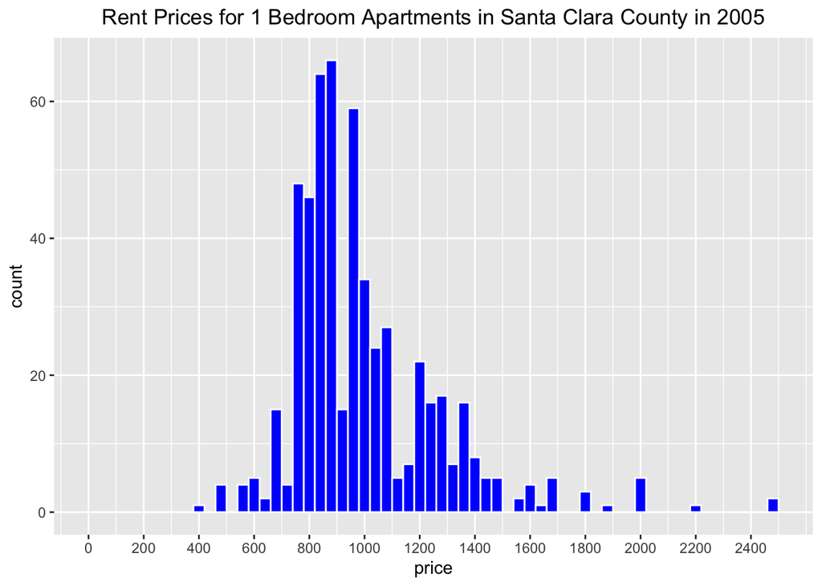

```r
# Histogram for rent price for 1 bedroom house in Santa Clara in 2005

rent |>
  filter(beds == "1", year == "2005", county == "santa clara") |>
  ggplot(aes(x=price)) +
  geom_histogram(binwidth = 40, color = "white", fill = "blue") +
  ggtitle("Rent Prices for 1 Bedroom Apartments in Santa Clara County in 2005") +
  theme(plot.title = element_text(hjust = 0.5)) +
  scale_x_continuous(breaks = seq(0, 2500, 200), lim = c(0, 2500))
```

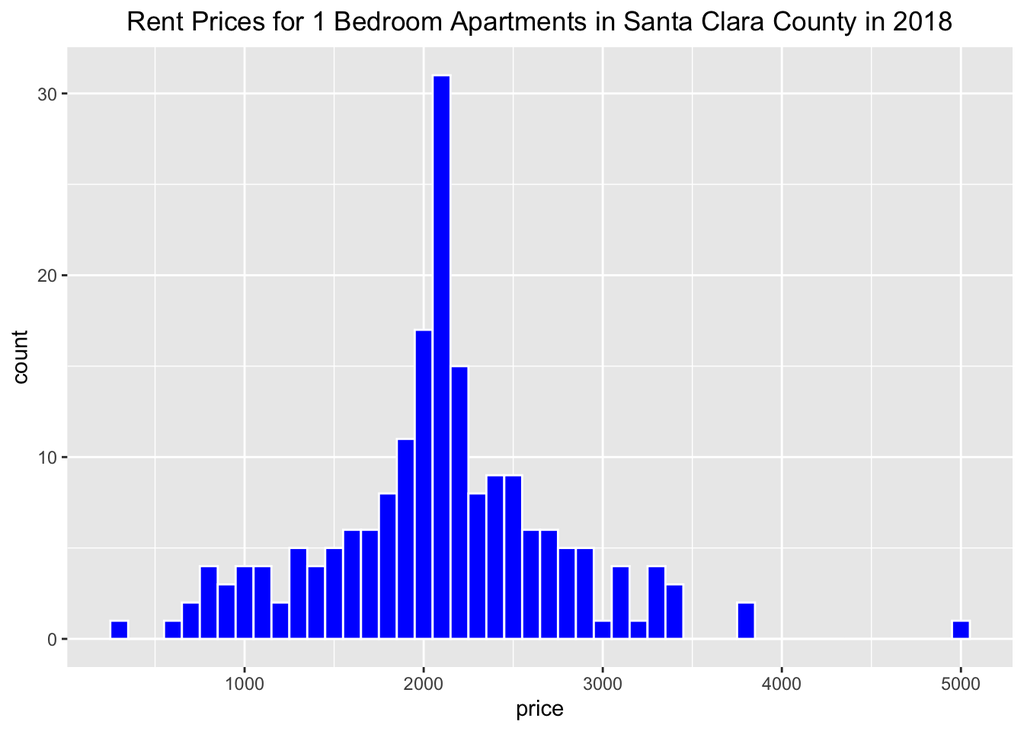

```r
# Histogram for rent price for 1 bedroom house in Santa Clara in 2018

rent |>
  filter(beds == "1", year == "2018", county == "santa clara") |>
  ggplot(aes(x=price)) +
  geom_histogram(binwidth = 100, color = "white", fill = "blue") +
  ggtitle("Rent Prices for 1 Bedroom Apartments in Santa Clara County in 2018") +
  theme(plot.title = element_text(hjust = 0.5))
```

The histogram for 2005 seems to have a bimodal distribution, with the first peak being around $850 and the second peak being around 950. In contrast, the histogram for 2018 only exhibits a unimodal distribution with the peak being around $2100. In comparison of both histograms, the 2005 histogram seems to have a right-skewed distribution, which leads us to believe that the median value would provide a more accurate representation of the average rent price for a 1 bedroom apartment in Santa Clara county in 2005. however, we can use the mean value from the 2018 histogram to estimate for the average rent price of a 1 bedroom apartment since the histogram has a fairly normal distribution.

### 5. Create and Interpret a line plot with year on the x-axis and median price for a 1 bedroom apartment for Santa Clara county on the y-axis from 2000 to 2018.

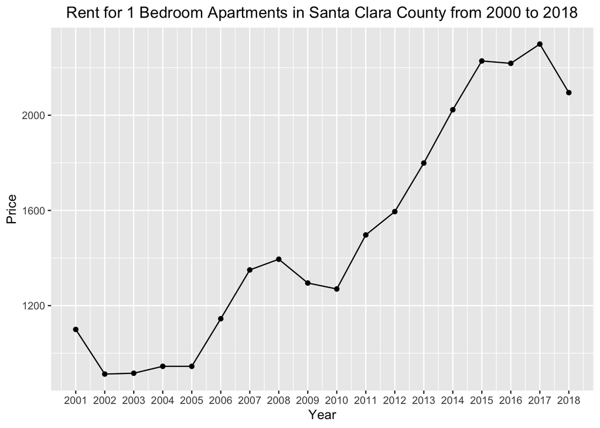

```r
# First filter the data into the subset we are interested in working with
# Find the median price for each year from 2000 to 2018
# Graph the median price against the years using a line graph

sc_years <- rent |>
  filter(county == "santa clara", beds == "1") |>
  group_by(year) |>
  summarise(med_year = median(price)) |>
  ungroup()

ggplot(sc_years, aes(x = year, y = med_year )) +
  geom_line() +
  geom_point() +
  scale_x_continuous(breaks = sc_years$year) +
  xlab("Year") +
  ylab("Price") +
  ggtitle("Rent for 1 Bedroom Apartments in Santa Clara County from 2000 to 2018") +
  theme(plot.title = element_text(hjust = 0.5))
```

### 6. Create and interpret a single plot with year on the x-axis and median price for a 1 bedroom apartment on the y-axis, using a separate line for each city in Santa Clara county, for the years 2000 to 2018.

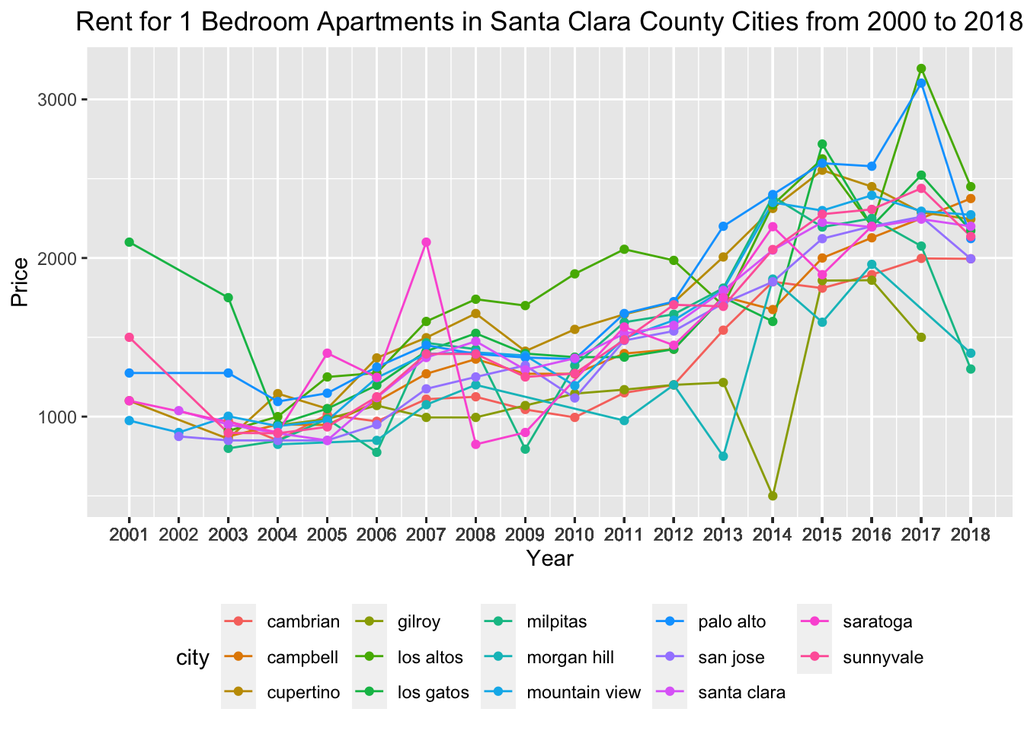

```r
# Group the subset by year and city before finding the median price for each year for each of the city within Santa Clara county
# Graph each city as their individual line within the line graph

cities_med <- rent |> filter(county == "santa clara", beds == "1") |>
  group_by(city, year) |>
  summarise(city_med = median(price))  |>
  ungroup()

ggplot(cities_med, aes(x = year, y = city_med, color = city )) +
  geom_line() +
  geom_point() +
  scale_x_continuous(breaks = cities_med$year) +
  xlab("Year") +
  ylab("Price") +
  ggtitle("Rent for 1 Bedroom Apartments in Santa Clara County Cities from 2000 to 2018") +
  theme(plot.title = element_text(hjust = 0.5), legend.position = "bottom")
```

The overall trend of the multi-lines graph shows an increase in rental price for a 1 bedroom apartment in cities within Santa Clara county from 2000 to 2018. However, when looking at individual lines by themselves, there are cities that have drastic fluctuations in rent price that could be consider abnormal when compared to the trend of other cities within the same time frame. An example of this would be Saratoga city having a steep increase in its median rent price from approximately $1300 in 2006 to a little over $2000 in 2007 and a steep decline in 2008 to less than $1000, this fluctuation is substantially different than the trend of the other cities that saw an overall increase within the same time frame. Another example of this would be Morgan Hill in 2013 and Gilroy in 2014 which saw a massive decrease in rent price in those two respective years when the rest of the other cities saw an increase in rent price. However, the median rent price in those two cities saw an equally drastic increase the year after, the two cities’ trend lines were now back to where the other cities were at in those respective years. Overall, due to the overcrowded nature of the line graph it is hard to make any meaningful interpretations or comparisons of any cities without making separate line graph for each city.

# B. Open ended data visualization

### 1. Research Questions

####1. Is the average rent price for a 1 bedroom apartment in San Francisco county significantly higher than the average rent price of all counties from 2000 to 2018?

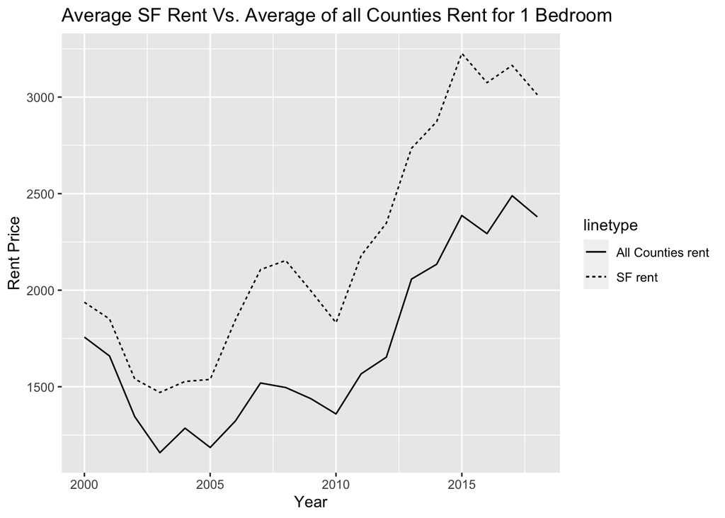

```r
# Create two subgroups, one for SF and one for the combined counties and both groups
# are looking at the average price of 1 bedroom apartments in 2018
# Plot the change in the average price over the 18 years time period

sf_rent <- rent |> filter(county == "san francisco", beds == "1") |>
  group_by(year) |>
  summarise(sf_avg = mean(price))  |>
  ungroup()

all_rent <- rent|> filter(beds == "1") |>
  group_by(year) |>
  summarise(all_avg = mean(price))  |>
  ungroup()

df_rent <- merge(all_rent, sf_rent, by.x = "year", by.y = "year", all = T)

ggplot(df_rent, aes(x = year, y = all_avg)) +
  geom_line(aes(y = sf_avg, linetype = "SF rent")) +
  geom_line(aes(y = all_avg, linetype = "All Counties rent")) +
  ggtitle("Average SF Rent Vs. Average of all Counties Rent for 1 Bedroom") +
  xlab("Year") +
  ylab("Rent Price")
```

```r
  theme(plot.title = element_text(hjust = 0.5))
```

[output not shown]

As shown in the line graph above, the average rent price for a 1 bedroom apartment in San Francisco County has always been above the total average rent price of all 10 counties combined. However, the gap in the differences in the rental price became larger from approximately 2002 onward and the gap seems to widen over the years since then. We can observe that in 2000 the differences between the two groups was only $200 in rent price for a 1 bedroom apartment, however, by 2018 the differences tripled and the gap in pricing became roughly $600 on average. Another thing to note, the fluctuation in the average rent price for San Francisco county follows the same fluctuation in the average rent price of all counties combined, with a notable characteristics that these fluctuation events seems to be more prominent in the SF rent trend line. There could be a few explanation for why this is happening, the first which could be the likely explanation, is that the average rent in San Francisco county could be following the statewide rental pricing trend of the state, The second explanation which is a more worrying factor, is that the average rent for a 1 bedroom apartment for San Francisco county is influencing the trend of the average rent of the combined counties due to how drastically more expensive San Francisco is compared to the other counties.

####2. Which county have the highest total numbers of listings in 2018?

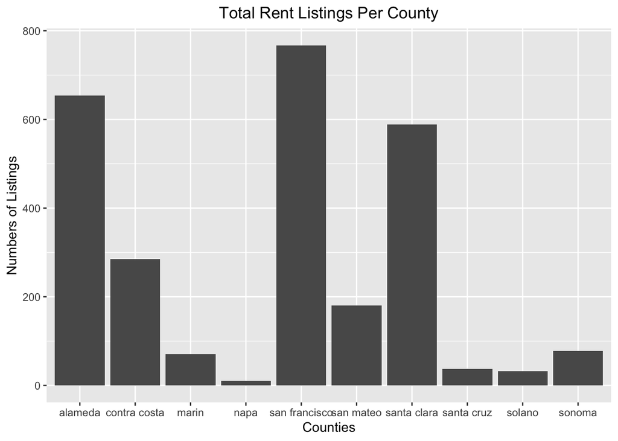

```r
# sum all of the listings for each of the county
# plot the number of listings per county on the bar graph

rent |> filter(year == "2018") |>
  group_by(county) |>
  summarise( n = n()) |>
  drop_na() |>
  ggplot(aes(x=county, y= n)) +
  geom_bar(stat="identity") +
  ggtitle("Total Rent Listings Per County") +
  xlab("Counties") +
  ylab("Numbers of Listings") +
  theme(plot.title = element_text(hjust = 0.5))
```

The bar graph shows that the three counties with the highest number of rental listings in 2018 are San Francisco, Alameda, and Santa Clara counties in the order from most to least listings. Since the three counties are considered to be highly urbanized areas due to being centers for fast-growing industries that provide a wealth of employment opportunities for job-seekers both locally and globally, therefore, the demand for living accommodations from job-seekers would then reflect accordingly in the high number of rental listings available in 2018. In comparison, for viticulture areas such as Napa and Solano counties see a very low numbers of listings in 2018 as a reflection of their highly specialized employment opportunities, unless individuals possess certain highly niche skillets relevant to the wine-making industry there are not a lot of other jobs available to attract job-seekers to the area. As a result, the lack of individuals moving into the area would drive the demand for rental units down and cause there to be few rental listings posted for Napa and Solano counties.

#### 3. What is the price distribution for a 1 bedroom apartment for the two counties with the highest total number of listings in 2018?

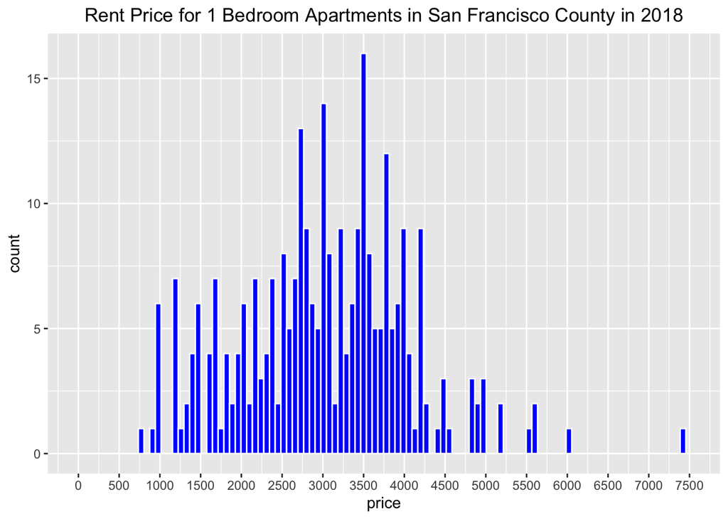

```r
# Plot histogram for price of 1 bedroom apartment for Alameda county in 2018

rent |>
  filter(beds == "1", year == "2018", county == "san francisco") |>
  ggplot(aes(x=price)) +
  geom_histogram(binwidth = 70, color = "white", fill = "blue") +
  ggtitle("Rent Price for 1 Bedroom Apartments in San Francisco County in 2018") +
  theme(plot.title = element_text(hjust = 0.5)) +
  scale_x_continuous(breaks = seq(0, 7500, 500), lim = c(0, 7500))
```

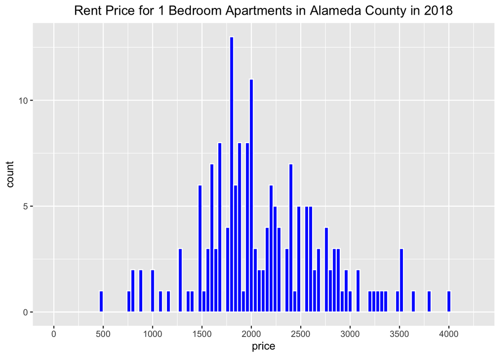

```r
# Plot histogram for price of 1 bedroom apartment for Alameda county in 2018

rent |>
  filter(beds == "1", year == "2018", county == "alameda") |>
  ggplot(aes(x=price)) +
  geom_histogram(binwidth = 40, color = "white", fill = "blue") +
  ggtitle("Rent Price for 1 Bedroom Apartments in Alameda County in 2018") +
  theme(plot.title = element_text(hjust = 0.5)) +
  scale_x_continuous(breaks = seq(0, 4250, 500), lim = c(0, 4250))
```